# Basic DE downstream of piscem

Author

Rob Patro

**Note**: This basic tutorial follows the same structure as the excellent [RNA-seq workflow: gene-level exploratory analysis and differential expression](https://www.bioconductor.org/help/course-materials/2019/CSAMA/materials/labs/lab-03-rnaseq/rnaseqGene_CSAMA2019.html) vignette, but demonstrates the `tximport` support for `piscem`, and also strips out a lot of the interesting exploratory analysis to just get to a basic DE result.

## Loading the required packages

In order to perform our analysis, we will need a few packages installed. The below code assumes that all of them are already installed, **with the exception of tximport**, which we need to install from GitHub, as the support for `piscem` is not yet available upstream in the current `BioConductor` release.

```r
devtools::install_github("https://github.com/thelovelab/tximport.git")
library(tximport)
library(dplyr)
library(arrow)
library("DESeq2")
library("PoiClaClu")
library("pheatmap")
library("RColorBrewer")
```

## Loading the sample table and transcript-to-gene map

We’ll read in the run table that contains the relevant information about the samples.

```r
dir <- file.path('.')
coldata <- read.delim(file.path(dir, "SraRunTable.txt"), sep=',')
colnames(coldata)
```

```
 [1] "Run"                 "Assay.Type"          "AvgSpotLen"
 [4] "Bases"               "BioProject"          "BioSample"
 [7] "Bytes"               "cell_line"           "cell_type"
[10] "Center.Name"         "Consent"             "DATASTORE.filetype"
[13] "DATASTORE.provider"  "DATASTORE.region"    "ercc_mix"
[16] "Experiment"          "GEO_Accession..exp." "Instrument"
[19] "LibraryLayout"       "LibrarySelection"    "LibrarySource"
[22] "Organism"            "Platform"            "ReleaseDate"
[25] "create_date"         "version"             "Sample.Name"
[28] "source_name"         "SRA.Study"           "tissue"
[31] "treatment"
```

Then, we strip down the run table to just the most basic information.

```r
samples_of_interest <- c("SRR1039508", "SRR1039509", "SRR1039512", "SRR1039513", "SRR1039516", "SRR1039517", "SRR1039520", "SRR1039521")
idx <- c("Run","cell_line","treatment")
coldata <- coldata[,idx]
colnames(coldata) <- c("run","cell","dex")
coldata <- coldata[coldata$run %in% samples_of_interest,]
coldata
```

```
          run    cell           dex
1  SRR1039508  N61311     Untreated
2  SRR1039509  N61311 Dexamethasone
5  SRR1039512 N052611     Untreated
6  SRR1039513 N052611 Dexamethasone
9  SRR1039516 N080611     Untreated
10 SRR1039517 N080611 Dexamethasone
13 SRR1039520 N061011     Untreated
14 SRR1039521 N061011 Dexamethasone
```

```r
coldata$dex <- recode_factor(coldata$dex, Untreated = "untrt", Dexamethasone = "trt")
levels(coldata$dex)
```

```
[1] "untrt" "trt"
```

```r
coldata$dex <- relevel(coldata$dex, "untrt")
coldata$dex
```

```
[1] untrt trt   untrt trt   untrt trt   untrt trt
Levels: untrt trt
```

We are doing a gene-level analysis, so we’ll need a transcript to gene mapping (that file can be obtained here).

```r
tx2gene <- read.csv("t2g.csv")
```

## Loading the `piscem` quantifications

The function we’ll use to load the quantifications.

```r
load_quants <- function(dir, coldata, tx2gene) {
  files <- as.character(lapply(file.path(dir, "quant", coldata$run), function(x) { paste0(x, ".quant") }))
  names(files) <- coldata$run
  txi <- tximport::tximport(files, type="piscem", tx2gene=tx2gene, ignoreAfterBar=TRUE)
  txi
}
```

Now, we can call this function:

```r
txi <- load_quants(dir, coldata, tx2gene)
```

```
reading in files with read_tsv
```

```
1 2 3 4 5 6 7 8
summarizing abundance
summarizing counts
summarizing length
summarizing inferential replicates
```

## Showing the heatmap

```r
dds <- DESeqDataSetFromTximport(txi, coldata, design = ~cell + dex)
```

```
using counts and average transcript lengths from tximport
```

```r
dds <- dds[ rowSums(counts(dds)) > 1, ]
dds
```

```
class: DESeqDataSet
dim: 35156 8
metadata(1): version
assays(2): counts avgTxLength
rownames(35156): ENSG00000000003.16 ENSG00000000419.14 ...
  ENSG00000292366.1 ENSG00000292372.1
rowData names(0):
colnames(8): SRR1039508 SRR1039509 ... SRR1039520 SRR1039521
colData names(3): run cell dex
```

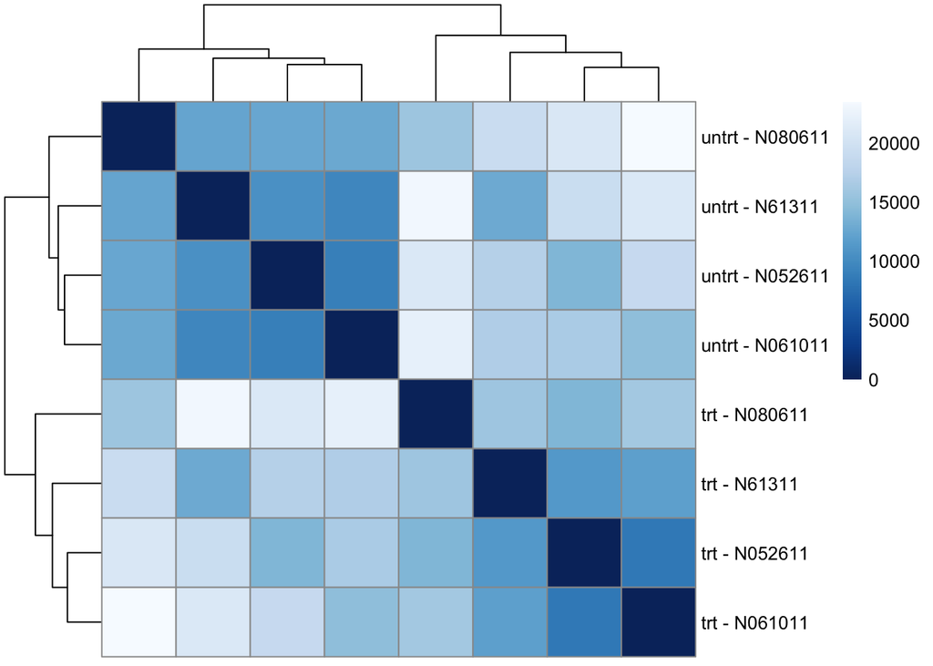

```r
poisd <- PoissonDistance(t(counts(dds)))
samplePoisDistMatrix <- as.matrix( poisd$dd )
colors <- colorRampPalette(rev(brewer.pal(9, "Blues")))(255)
rownames(samplePoisDistMatrix) <- paste( dds$dex, dds$cell, sep=" - " )
colnames(samplePoisDistMatrix) <- NULL
pheatmap(samplePoisDistMatrix,
         clustering_distance_rows = poisd$dd,
         clustering_distance_cols = poisd$dd,
         col = colors)
```

## Computing DEGs

The `compute_degs` function below will do what is necessary to compute the actual differential result table using `DESeq2`.

```r
compute_degs <- function(dds, coldata) {
  dds <- DESeq(dds)
  res <- results(dds)
  res
}
```

We get the result by calling the function:

```r
degs <- compute_degs(dds, coldata)
```

show the results:

```r
degs <- degs[!is.na(degs$padj),]
degs[degs$padj < 0.05,]
```

```
log2 fold change (MLE): dex trt vs untrt
Wald test p-value: dex trt vs untrt
DataFrame with 3478 rows and 6 columns
                     baseMean log2FoldChange     lfcSE      stat      pvalue
                    <numeric>      <numeric> <numeric> <numeric>   <numeric>
ENSG00000000003.16    745.167      -0.420638 0.1244011  -3.38130 7.21431e-04
ENSG00000000971.17   5721.921       0.461468 0.0804752   5.73429 9.79191e-09
ENSG00000001167.15    481.664      -0.529965 0.1450754  -3.65303 2.59164e-04
ENSG00000002834.19   8609.485       0.419376 0.0969321   4.32649 1.51502e-05
ENSG00000003096.15    414.807      -0.970928 0.1377851  -7.04669 1.83229e-12
...                       ...            ...       ...       ...         ...
ENSG00000291132.1    334.5893      -0.616538  0.148620  -4.14841 3.34799e-05
ENSG00000291143.1     11.5454       2.607125  0.848655   3.07207 2.12582e-03
ENSG00000291214.1    293.0346      -0.541151  0.177173  -3.05436 2.25539e-03
ENSG00000291237.1  14395.7583       0.509307  0.151184   3.36880 7.54971e-04
ENSG00000292339.1    379.0986       0.522643  0.140373   3.72324 1.96685e-04
                          padj
                     <numeric>
ENSG00000000003.16 5.54837e-03
ENSG00000000971.17 2.19155e-07
ENSG00000001167.15 2.28902e-03
ENSG00000002834.19 1.86395e-04
ENSG00000003096.15 6.36374e-11
...                        ...
ENSG00000291132.1  0.000382518
ENSG00000291143.1  0.013978534
ENSG00000291214.1  0.014716467
ENSG00000291237.1  0.005778280
ENSG00000292339.1  0.001805790
```